In this vignette we compare computational requirements (time and memory) of common operations using `data.table` and tidyverse functions.

## Setup

```r
library(data.table)
as.integer(Sys.getenv("SLURM_JOB_CPUS_PER_NODE", "1"))
```

```
#> [1] 1
```

```r
max.threads <- parallel::detectCores()
threads.vec <- unique(as.integer(c(1, max.threads/2, max.threads)))
is.toby <- system("whoami", intern=TRUE) %in% c("tdhock", "nau\\th798")
##seconds.limit <- if(is.toby)1 else 0.01
seconds.limit <- 1
aplot <- function(atime.list, my.title, xmax, max.seconds, xlab, color.vec=NULL){
  best.list <- atime::references_best(atime.list)
  both.dt <- best.list$meas
  blank.dt <- data.table(x=both.dt$N[1], y=max.seconds, unit="seconds")
  if(require(ggplot2)){
    hline.df <- with(atime.list, data.frame(seconds.limit, unit="seconds"))
    gg <- ggplot()+
      ggtitle(my.title)+
      theme_bw()+
      geom_blank(aes(
        x, y),
        data=blank.dt)+
      facet_grid(unit ~ ., scales="free")+
      geom_hline(aes(
        yintercept=seconds.limit),
        color="grey",
        data=hline.df)+
      geom_line(aes(
        N, empirical, color=expr.name),
        data=best.list$meas)+
      geom_ribbon(aes(
        N, ymin=min, ymax=max, fill=expr.name),
        data=best.list$meas[unit=="seconds"],
        alpha=0.5)+
      scale_x_log10(xlab)+
      scale_y_log10("median line, min/max band")
    if(!is.null(color.vec)){
      gg <- gg+
        scale_color_manual(values=color.vec)+
        scale_fill_manual(values=color.vec)
    }
    if(require(directlabels)){
      gg+
        directlabels::geom_dl(aes(
          N, empirical, color=expr.name, label=expr.name),
          method="right.polygons",
          data=best.list$meas)+
        theme(legend.position="none")+
        coord_cartesian(xlim=c(NA,xmax))
    }else{
      gg
    }
  }
}
```

## Writing CSV

First we define some code which will be used in all of the writing benchmarks,

```r
atime_write <- function(make.mat.fun, fmt){
  atime::atime(
    N=10^seq(1, 7),
    setup={
      mat <- make.mat.fun(N)
      name.list <- list()
      for(fun in c("fwrite", "write_csv", "write.csv")){
        name.list[[fun]] <- file.path(
          tempdir(), sprintf(fmt, fun, N))
      }
      dt <- data.table(mat)
    },
    seconds.limit = seconds.limit,
    results=FALSE,
    expr.list=atime::atime_grid(
      list(THREADS=threads.vec),
      "data.table::fwrite"={
        data.table::setDTthreads(THREADS)
        data.table::fwrite(dt, name.list$fwrite, showProgress = FALSE)
      },
      "readr::write_csv"={
        readr::write_csv(
          dt, name.list$write_csv, progress = FALSE, num_threads = THREADS)
      }),
    "utils::write.csv"=utils::write.csv(dt, name.list$write.csv))
}
if(FALSE){
  RColorBrewer::display.brewer.all()
  dput(RColorBrewer::brewer.pal(Inf, "Set2"))
  dput(RColorBrewer::brewer.pal(Inf, "RdGy"))
}
PRGn <- c(
  "#40004B", "#762A83", "#9970AB", "#C2A5CF", "#E7D4E8",
  "#F7F7F7",
  "#D9F0D3", "#A6DBA0", "#5AAE61", "#1B7837", "#00441B")
expr.colors <- c(
  "#67001F",#dark red
  "#B2182B", "#D6604D", "#F4A582", "#FDDBC7",
  "#FFFFFF",#white
  "#E0E0E0", "#BABABA", "#878787", "#4D4D4D",
  "#1A1A1A",#almost black
  "utils::write.csv"="deepskyblue")
names(expr.colors)[c(3,2,1)] <- paste0(
  "data.table::fwrite THREADS=",threads.vec)
names(expr.colors)[c(9,10,11)] <- paste0(
  "readr::write_csv THREADS=",threads.vec)
write.colors <- expr.colors[names(expr.colors)!=""]
```

The code below is for real numbers with a constant number of columns, and a variable number of rows.

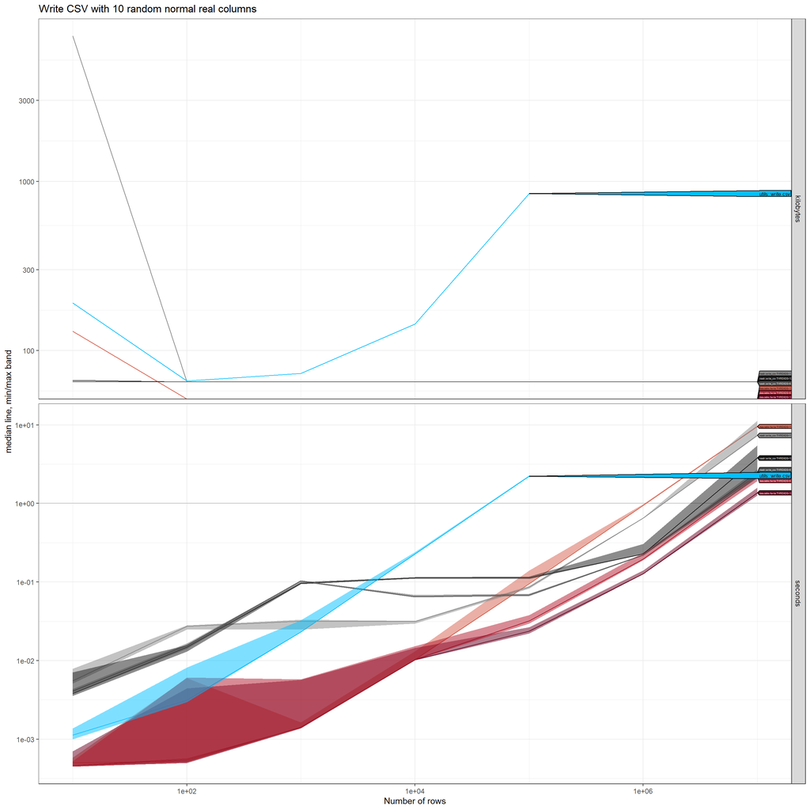

```r
random_real <- function(N.rows, N.cols){
  set.seed(1)
  matrix(rnorm(N.rows*N.cols), N.rows, N.cols)
}
write.real.vary.rows <- atime_write(
  function(N.rows, N.cols=10)random_real(N.rows, N.cols),
  "10_real_cols_%s_%d.csv")
aplot(write.real.vary.rows, "Write CSV with 10 random normal real columns", 1e7, 1e1, "Number of rows", write.colors)
```

The code below writes real numbers with a constant number of rows, and a variable number of columns.

```r
write.real.vary.cols <- atime_write(
  function(N.cols, N.rows=10)random_real(N.rows, N.cols),
  "10_real_rows_%s_%d.csv")
```

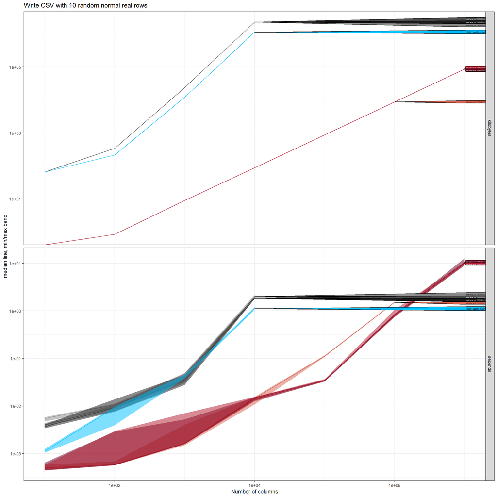

```r
aplot(write.real.vary.cols, "Write CSV with 10 random normal real rows", 1e7, 1e1, "Number of columns", write.colors)
```

The code below is for character data with a constant number of columns, and a variable number of rows.

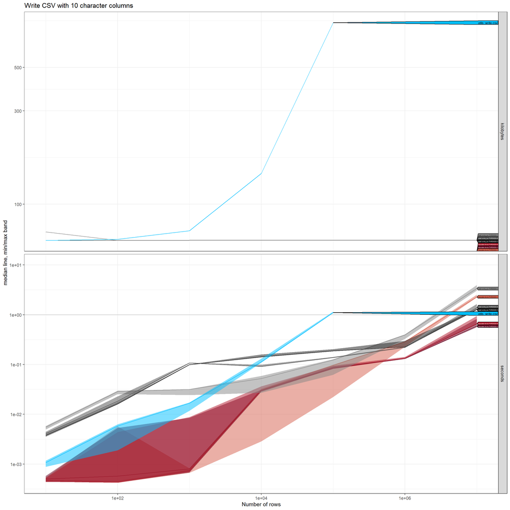

```r
chr_mat <- function(N.rows, N.cols){
  matrix("'quoted data'", N.rows, N.cols)
}
write.chr.vary.rows <- atime_write(
  function(N.rows,N.cols=10)chr_mat(N.rows, N.cols),
  "10_chr_cols_%s_%d.csv")
aplot(write.chr.vary.rows, "Write CSV with 10 character columns", 1e7, 1e1, "Number of rows", write.colors)
```

The code below is for character data with a constant number of rows, and a variable number of columns.

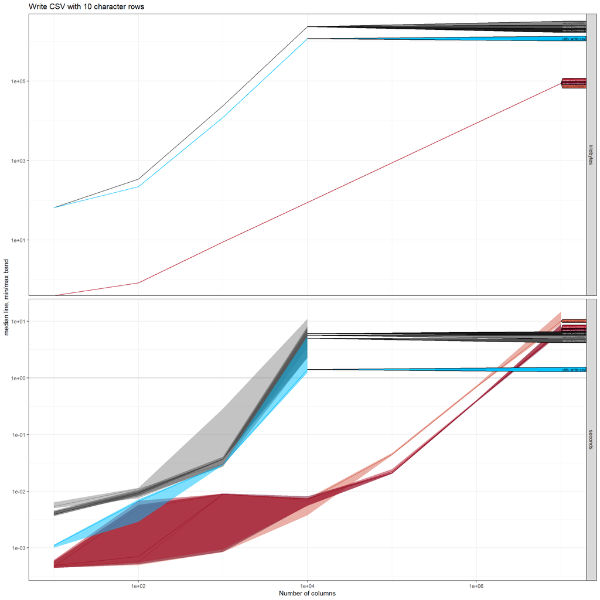

```r
write.chr.vary.cols <- atime_write(
  function(N.cols, N.rows=10)chr_mat(N.rows, N.cols),
  "10_chr_rows_%s_%d.csv")
aplot(write.chr.vary.cols, "Write CSV with 10 character rows", 1e7, 1e1, "Number of columns", write.colors)
```

## Reading CSV

First we define a function which we will use for all of the read benchmarks,

```r
read.expr.list <- c(atime::atime_grid(
  list(LAZY=c(TRUE, FALSE), THREADS=threads.vec),
  "readr::read_csv"=readr::read_csv(
    f.csv, num_threads = THREADS, lazy = LAZY,
    show_col_types=FALSE, progress=FALSE)),
  atime::atime_grid(
    list(THREADS=threads.vec),
    "data.table::fread"={
      data.table::setDTthreads(THREADS)
      data.table::fread(f.csv, showProgress=FALSE)
    }),
  "utils::read.csv"=quote(utils::read.csv(f.csv)))
atime_read <- function(glob){
  fmt <- sub("[*]", "%d", glob)
  csv.dt <- nc::capture_first_vec(
    Sys.glob(file.path(tempdir(), glob)),
    N="[0-9]+", as.integer,
    ".csv")[order(N)]
  atime::atime(
    N=csv.dt$N,
    setup={
      f.csv <- file.path(tempdir(), sprintf(fmt, N))
    },
    seconds.limit = seconds.limit,
    results=FALSE,
    expr.list=read.expr.list)
}
PRGn <- c(
  "#40004B", "#762A83", "#9970AB", "#C2A5CF", "#E7D4E8",#5
  "#F7F7F7", #6
  "#D9F0D3", "#A6DBA0", "#5AAE61", "#1B7837", "#00441B",#11
  "#67001F",#dark red 12
  "#B2182B", "#D6604D", "#F4A582", "#FDDBC7",
  "#FFFFFF",#white 17
  "#E0E0E0", "#BABABA", "#878787", "#4D4D4D",
  "#1A1A1A",#almost black 22
  "utils::write.csv"="deepskyblue")
names(PRGn)[c(3,2,1,9,10,11,14,13,12,23)] <- names(read.expr.list)
read.colors <- PRGn[names(PRGn)!=""]
```

Below we read real numbers with a constant number of columns, and a variable number of rows.

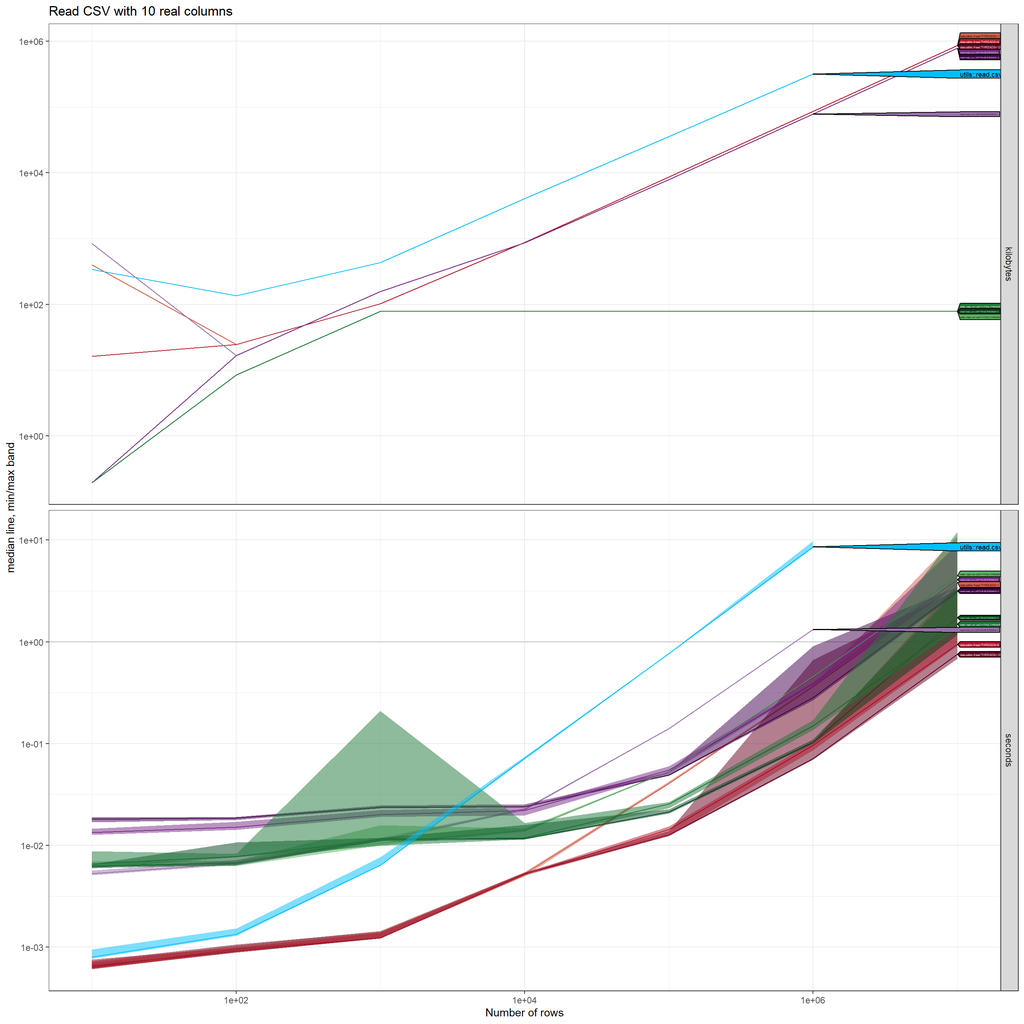

```r
read.real.vary.rows <- atime_read("10_real_cols_fwrite_*.csv")
aplot(read.real.vary.rows, "Read CSV with 10 real columns", 1e7, 1e1, "Number of rows", read.colors)
```

Below we read real numbers with a constant number of rows, and a variable number of columns.

```r
read.real.vary.cols <- atime_read("10_real_rows_fwrite_*.csv")
```

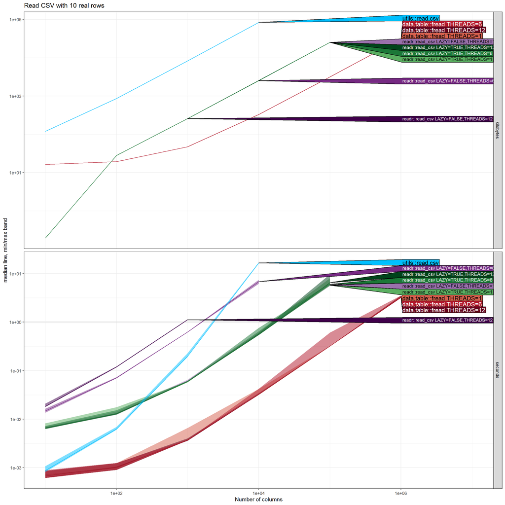

```r
aplot(read.real.vary.cols, "Read CSV with 10 real rows", 1e7, 1e1, "Number of columns", read.colors)
```

Below we read character data with a constant number of columns, and a variable number of rows.

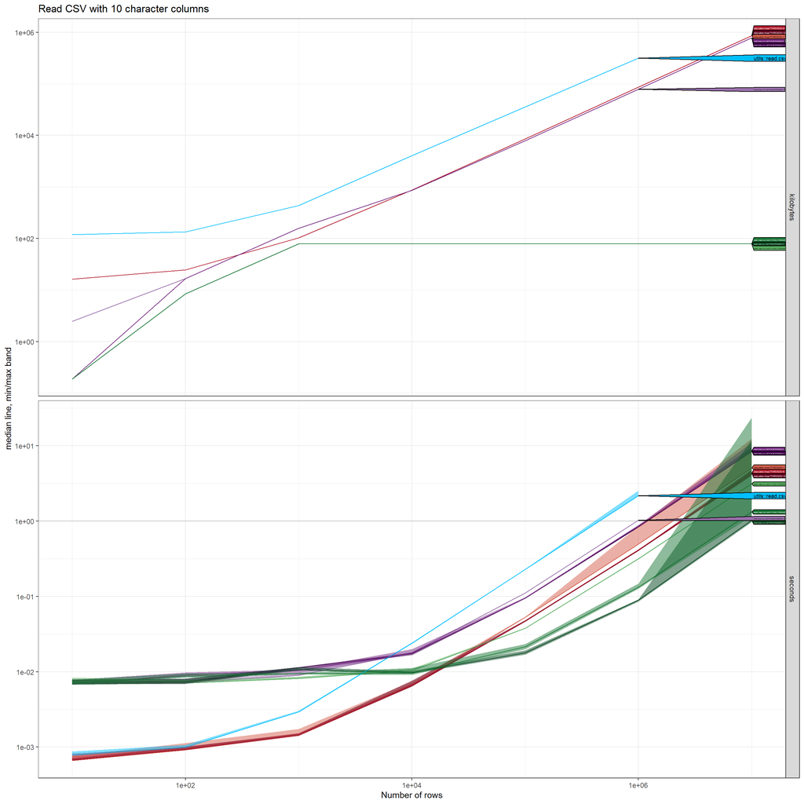

```r
read.chr.vary.rows <- atime_read("10_chr_cols_fwrite_*.csv")
aplot(read.chr.vary.rows, "Read CSV with 10 character columns", 1e7, 1e1, "Number of rows", read.colors)
```

Below we read character data with a constant number of rows, and a variable number of columns.

```r
read.chr.vary.cols <- atime_read("10_chr_rows_fwrite_*.csv")
```

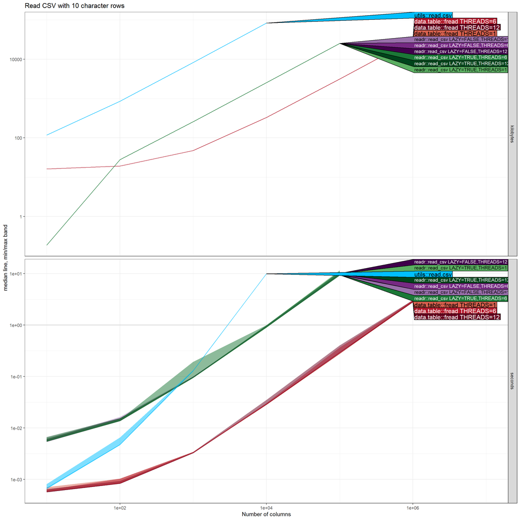

```r
aplot(read.chr.vary.cols, "Read CSV with 10 character rows", 1e7, 1e1, "Number of columns", read.colors)
```

## Summarize by group

The next problem is motivated by a common operation in machine learning code: computing the mean/SD over cross-validation folds.

```r
summary.expr.list <- c(atime::atime_grid(
  list(THREADS=threads.vec),
  "[.data.table"={
    data.table::setDTthreads(THREADS)
    loss.dt[, .(
      loss_length=.N,
      loss_mean=mean(loss),
      loss_sd=sd(loss)
    ), by=.(set, epoch)]
  }),
  atime::atime_grid(
    "base::by"={
      base::by(
        loss.dt$loss,
        list(loss.dt$set, loss.dt$epoch),
        function(values)c(
          loss_length=length(values),
          loss_mean=mean(values),
          loss_sd=sd(values)))
    },
    "base::tapply"={
      base::tapply(
        loss.dt$loss,
        list(loss.dt$set, loss.dt$epoch),
        function(values)c(
          loss_length=length(values),
          loss_mean=mean(values),
          loss_sd=sd(values)))
    },
    "stats::aggregate"={
      res <- stats::aggregate(
        loss ~ set + epoch,
        loss.dt,
        function(values)list(c(
          loss_length=length(values),
          loss_mean=mean(values),
          loss_sd=sd(values))))
      data.frame(
        subset(res, select=-loss),
        do.call(rbind, res$loss))
    },
    "data.table::dcast"={
      dcast(
        loss.dt,
        set + epoch ~ .,
        list(length, mean, sd),
        value.var="loss")
    },
    "dplyr::summarise"={
      loss.dt |>
      dplyr::group_by(set, epoch) |>
      dplyr::summarise(
        loss_length=length(loss),
        loss_mean=mean(loss),
        loss_sd=sd(loss))
    },
    "tidyr::pivot_wider"={
      loss.dt |>
      tidyr::pivot_wider(
        id_cols = c(set,epoch),
        values_from=loss,
        names_from=name,
        values_fn=function(values)list(c(
          loss_length=length(values),
          loss_mean=mean(values),
          loss_sd=sd(values)))) |>
          tidyr::unnest_wider(loss)
    }))
summary.colors <- c(
  "#D6604D",
  "#B2182B",
  "#67001F",#dark red
  "#66C2A5", "#FC8D62", "#8DA0CB", "#E78AC3", "#A6D854", "#FFD92F",
  "#E5C494", "#B3B3B3")
names(summary.colors)[1:length(summary.expr.list)] <- names(summary.expr.list)
summary.colors <- summary.colors[names(summary.colors)!=""]
options(dplyr.summarise.inform=FALSE)
summary.atime.list <- atime::atime(
  N=as.integer(10^seq(0, 7, by=0.5)),
  setup={
    n.folds <- 10
    loss.dt <- data.table(
      name="loss",
      fold=rep(1:n.folds, each=2*N),
      loss=rnorm(2*N*n.folds),
      set=rep(c("subtrain","validation"),each=N),
      epoch=1:N,
      key=c("set","epoch","fold"))
  },
  results=FALSE,
  seconds.limit=seconds.limit,
  expr.list=summary.expr.list)

```

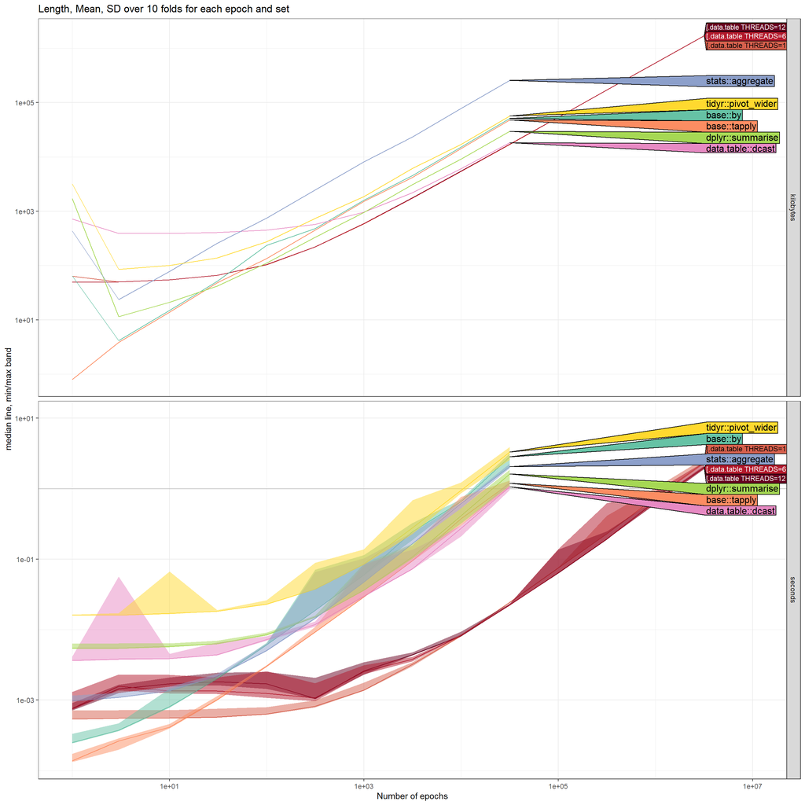

```r
aplot(summary.atime.list, "Length, Mean, SD over 10 folds for each epoch and set", 1e7, 1e1, "Number of epochs", summary.colors)
```

## Join / merge

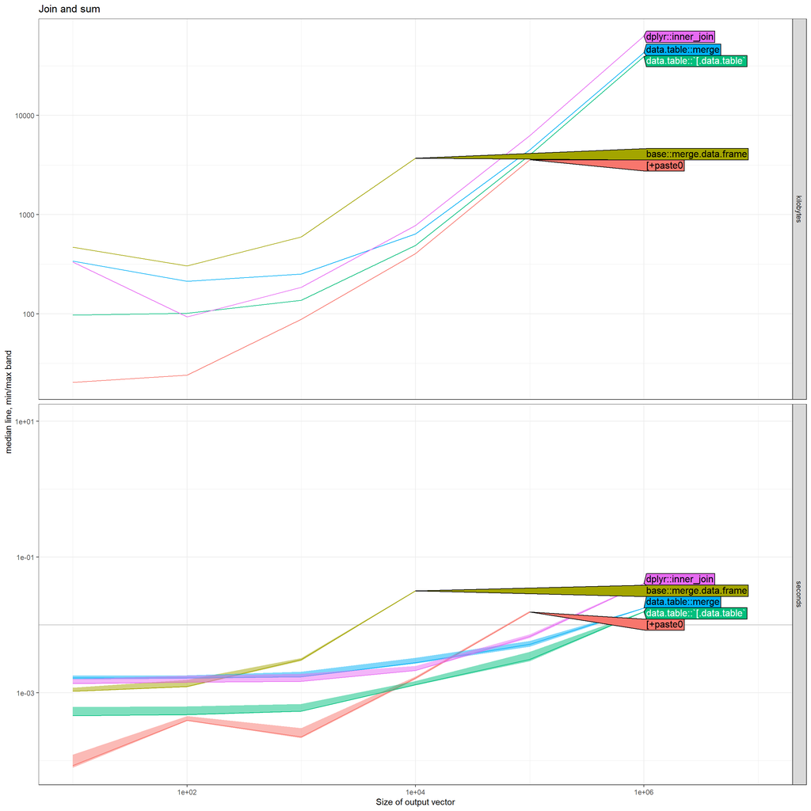

```r
i <- 1:100
DT <- CJ(letter=LETTERS, i)[, x := rnorm(.N)]
setkey(DT, letter, i)
DF <- data.frame(DT)
rownames(DF) <- with(DF, paste0(letter, i))
atime.list <- atime::atime(
  N=10^seq(1, 7),
  setup={
    select.dt <- data.table(
      letter=sample(LETTERS, N, replace=TRUE),
      i=sample(i, N, replace=TRUE),
      y=rnorm(N))
    setkey(select.dt, letter, i)
    select.df <- data.frame(select.dt)
  },
  "data.table::`[.data.table`"=DT[select.dt, x+y],
  "data.table::merge"=data.table::merge.data.table(DT,select.dt)[, x+y],
  "base::merge.data.frame"=with(base::merge.data.frame(DF, select.df, by=c('letter','i')), x+y),
  "[+paste0"=with(select.df, DF[paste0(letter,i),"x"]+y),
  "dplyr::inner_join"=with(dplyr::inner_join(DT, select.dt, by=c('letter','i')), x+y))
aplot(atime.list, "Join and sum", 1e7, 1e1, "Size of output vector")
```

## Join and summarize

```r
i <- 1:100
DT <- CJ(letter=LETTERS, i)[, x := rnorm(.N)]
setkey(DT, letter, i)
DF <- data.frame(DT)
rownames(DF) <- with(DF, paste0(letter, i))
atime.list <- atime::atime(
  N=as.integer(10^seq(0, 7, by=0.5)),
  setup={
    select.dt <- data.table(
      letter=sample(LETTERS, N, replace=TRUE),
      i=sample(i, N, replace=TRUE),
      y=rnorm(N))
    setkey(select.dt, letter, i)
    select.df <- data.frame(select.dt)
  },
  seconds.limit=seconds.limit,
  "data.table::`[.data.table`"={
    select.dt[DT, .(rows=.N, diff=mean(y)-x), by=.EACHI, nomatch=0L]
  },
  "base::by"={
    do.call(rbind, base::by(
      select.df,
      with(select.df, paste0(letter, i)),
      function(sdf){
        srow <- sdf[1,]
        data.frame(
          srow[,c("letter","i")],
          rows=nrow(sdf),
          diff=mean(sdf$y)-DF[with(srow,paste0(letter,i)),"x"])
      }))
  },
  "dplyr::inner_join"={
    dplyr::inner_join(DT, select.dt, by=c('letter','i')) |>
      dplyr::group_by(letter, i) |>
      dplyr::summarise(rows=length(y), diff=mean(y)-x[1])
  })

```

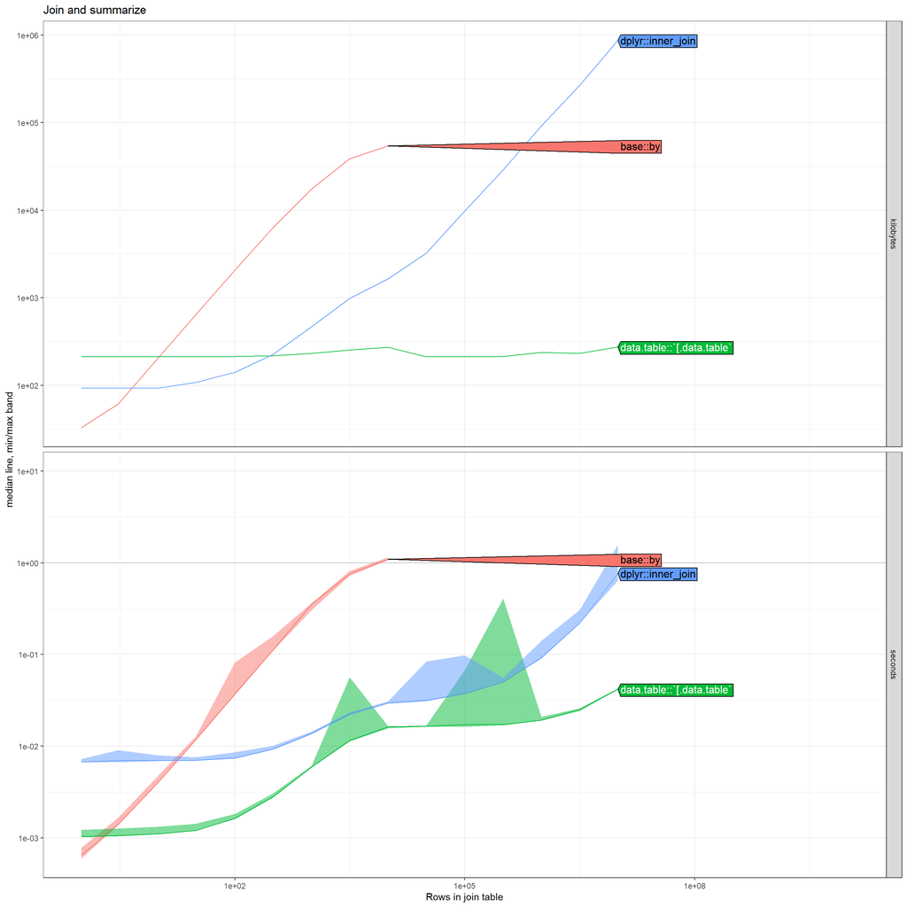

```r
aplot(atime.list, "Join and summarize", 1e10, 1e1, "Rows in join table")
```

## Rolling join

This situation arises when you want to compute the average in a regular grid over some irregularly spaced numbers.

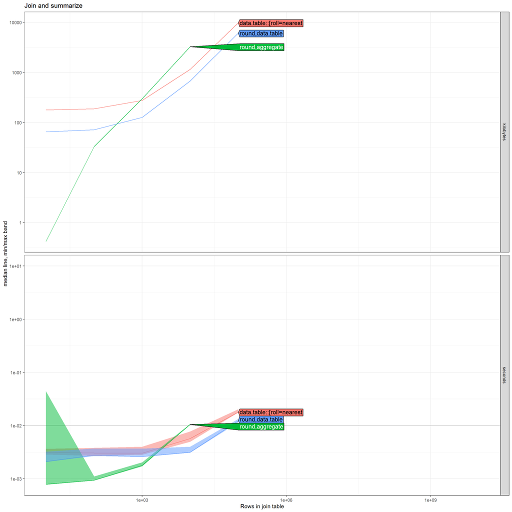

```r
digits <- 1
grid.space <- 10^(-digits)
offset <- grid.space/2
atime.list <- atime::atime(
  N=10^seq(1:7),
  setup={
    set.seed(1)
    X <- runif(N)
    Y <- 10*X+rnorm(N)
  },
  "data.table::[roll=nearest"={
    irreg.dt <- data.table(X, Y, key="X")
    grid <- seq(offset, 1-offset, by=grid.space)
    reg.dt <- data.table(grid, X=grid, key="X")
    join.dt <- reg.dt[irreg.dt, roll="nearest"]
    join.dt[, .(Y.N=.N, Y.mean=mean(Y), Y.sd=sd(Y)), by=grid]
  },
  "round,data.table"={
    data.table(
      grid=round(X+offset, digits=digits)-offset,
      Y
    )[, .(
      Y.N=.N,
      Y.mean=mean(Y),
      Y.sd=sd(Y)
    ), by=grid]
  },
  "round,aggregate"={
    grid <- round(X+offset, digits=digits)-offset
    aggregate(Y ~ grid, FUN=function(values)c(
      N=length(values),
      mean=mean(values),
      sd=sd(values)))
  })
aplot(atime.list, "Join and summarize", 1e10, 1e1, "Rows in join table")
```